# Radman_Rabea_Week3

## Fitting different kinds of models

```python
anscombe = sns.load_dataset("anscombe")
```

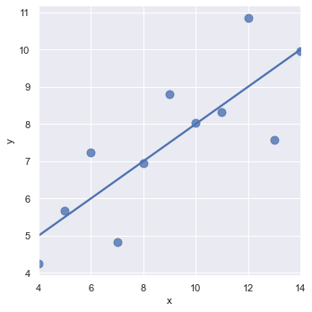

```python
sns.lmplot(x="x", y="y", data=anscombe.query("dataset == 'I'"),
           ci=None, scatter_kws={"s": 80});
```

The linear relationship in the second dataset is the same, but the plot clearly shows that this is not a good model:

[figure not shown]

```python
sns.lmplot(x="x", y="y", data=anscombe.query("dataset == 'II'"),
           robust = True, ci=None, scatter_kws={"s": 80});
```

In the presence of these kind of higher-order relationships, **`lmplot`** and **`regplot`** can fit a polynomial regression model to explore simple kinds of nonlinear trends in the dataset:

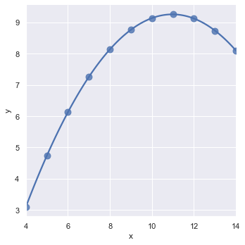

```python
sns.lmplot(x="x", y="y", data=anscombe.query("dataset == 'II'"),
           order=2, ci=None, scatter_kws={"s": 80});
```

A different problem is posed by "outlier" observations that deviate for some reason other than the main relationship under study:

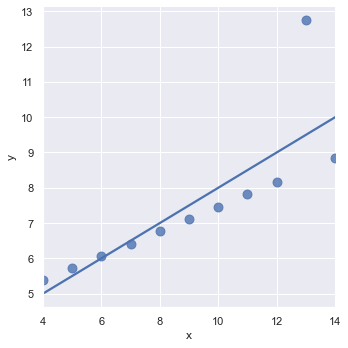

```python
sns.lmplot(x="x", y="y", data=anscombe.query("dataset == 'III'"),
           ci=None, scatter_kws={"s": 80});
```

In the presence of outliers, it can be useful to fit a robust regression, which uses a different loss function to downweight relatively large residuals:

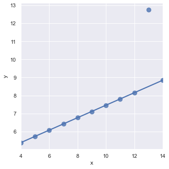

```python
sns.lmplot(x="x", y="y", data=anscombe.query("dataset == 'III'"),
         robust = True,  ci=None, scatter_kws={"s": 80});
```

When the `y` variable is binary, simple linear regression also "works" but provides implausible predictions:

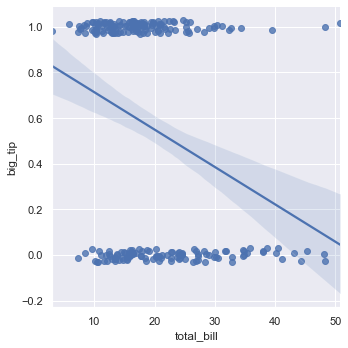

```python
tips["big_tip"] = (tips.tip / tips.total_bill) > .15
sns.lmplot(x="total_bill", y="big_tip", data=tips,
           y_jitter=.03);
```

The solution in this case is to fit a logistic regression, such that the regression line shows the estimated probability of `y = 1` for a given value of `x`:

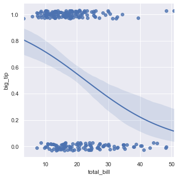

```python
sns.lmplot(x="total_bill", y="big_tip", data=tips,
           logistic=True, y_jitter=.03);
```

Note that the logistic regression estimate is considerably more computationally intensive (this is true of robust regression as well) than simple regression, and as the confidence interval around the regression line is computed using a bootstrap procedure, you may wish to turn this off for faster iteration (using `ci=None`).

An altogether different approach is to fit a nonparametric regression using a `lowess smoother <https://en.wikipedia.org/wiki/Local_regression>`_. This approach has the fewest assumptions, although it is computationally intensive and so currently confidence intervals are not computed at all:

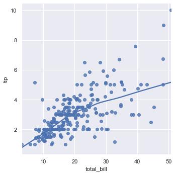

```python
sns.lmplot(x="total_bill", y="tip", data=tips,
           lowess=True);
```

The **`residplot`** function can be a useful tool for checking whether the simple regression model is appropriate for a dataset. It fits and removes a simple linear regression and then plots the residual values for each observation. Ideally, these values should be randomly scattered around `y = 0`:

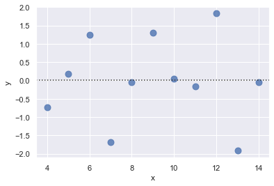

```python
sns.residplot(x="x", y="y", data=anscombe.query("dataset == 'I'"),
              scatter_kws={"s": 80});
```

If there is structure in the residuals, it suggests that simple linear regression is not appropriate:

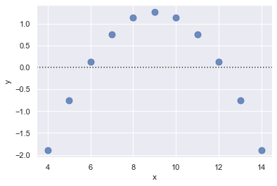

```python
sns.residplot(x="x", y="y", data=anscombe.query("dataset == 'II'"),
              scatter_kws={"s": 80});
```

## Conditioning on other variables

The plots above show many ways to explore the relationship between a pair of variables. Often, however, a more interesting question is "how does the relationship between these two variables change as a function of a third variable?" This is where the difference between **`regplot`** and **`lmplot`** appears. While **`regplot`** always shows a single relationship, **`lmplot`** combines **`regplot`** with **`FacetGrid`** to provide an easy interface to show a linear regression on "faceted" plots that allow you to explore interactions with up to three additional categorical variables.

The best way to separate out a relationship is to plot both levels on the same axes and to use color to distinguish them:

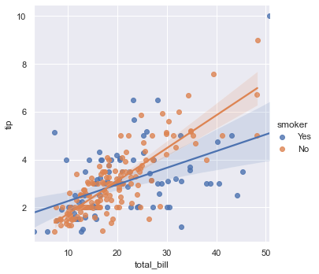

```python
sns.lmplot(x="total_bill", y="tip", hue="smoker", data=tips);
```

In addition to color, it's possible to use different scatterplot markers to make plots the reproduce to black and white better. You also have full control over the colors used:

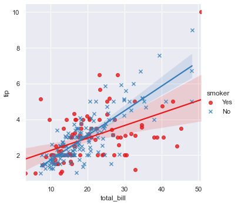

```python
sns.lmplot(x="total_bill", y="tip", hue="smoker", data=tips,
           markers=["o", "x"], palette="Set1");
```

To add another variable, you can draw multiple "facets" which each level of the variable appearing in the rows or columns of the grid:

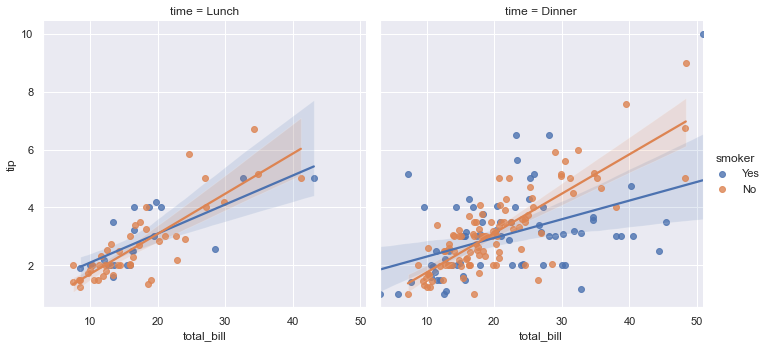

```python
sns.lmplot(x="total_bill", y="tip", hue="smoker", col="time", data=tips);
```

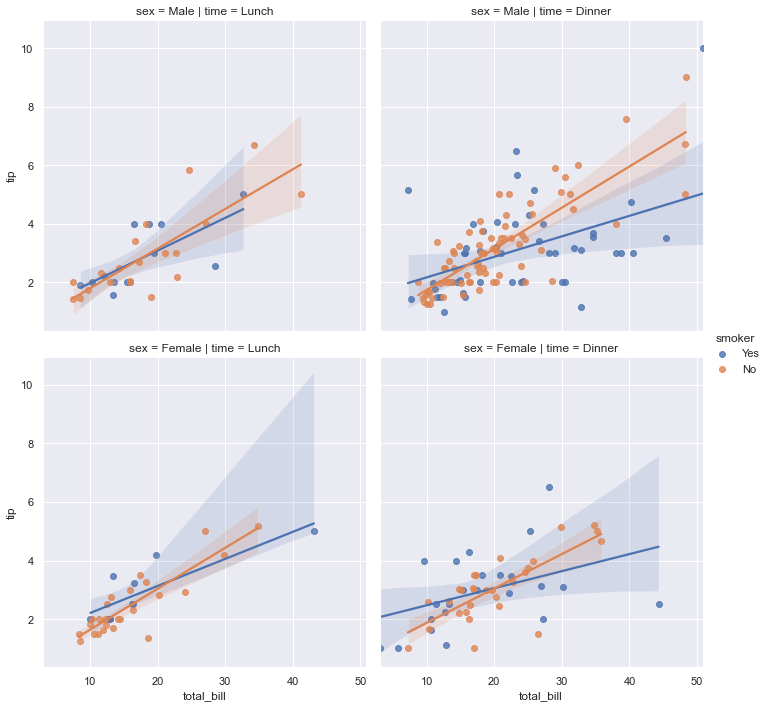

```python
sns.lmplot(x="total_bill", y="tip", hue="smoker",
           col="time", row="sex", data=tips);
```

## Controlling the size and shape of the plot

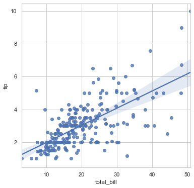

```python
f, ax = plt.subplots(figsize=(6, 6))
sns.regplot(x="total_bill", y="tip", data=tips, ax=ax);
```

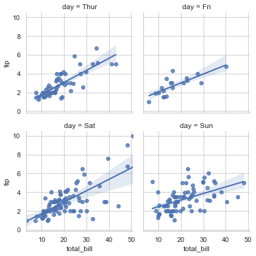

```python
sns.lmplot(x="total_bill", y="tip", col="day", data=tips,
           col_wrap=2, height=3);
```

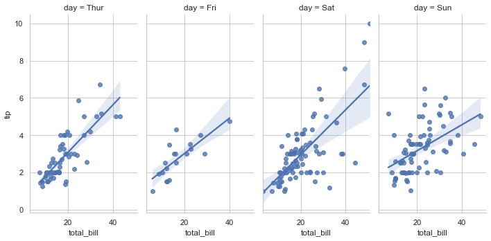

```python
sns.lmplot(x="total_bill", y="tip", col="day", data=tips,
           aspect=.5);
```

## Plotting a regression in other contexts

A few other seaborn functions use **`regplot`** in the context of a larger, more complex plot. The first is the **`jointplot`** function that we introduced in the :ref:`distributions tutorial <distribution_tutorial>`. In addition to the plot styles previously discussed, **`jointplot`** can use **`regplot`** to show the linear regression fit on the joint axes by passing `kind="reg"`:

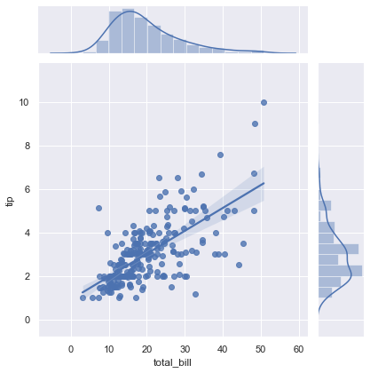

```python
sns.jointplot(x="total_bill", y="tip", data=tips, kind="reg");
```

Using the **`pairplot`** function with `kind="reg"` combines **`regplot`** and **`PairGrid`** to show the linear relationship between variables in a dataset. Take care to note how this is different from **`lmplot`**. In the figure below, the two axes don't show the same relationship conditioned on two levels of a third variable; rather, **`PairGrid`** is used to show multiple relationships between different pairings of the variables in a dataset:

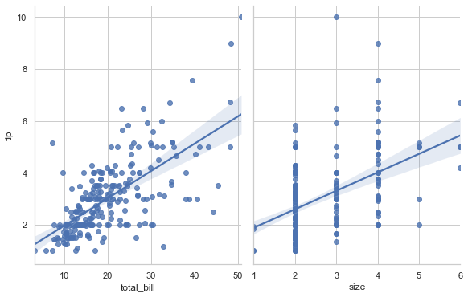

```python
sns.pairplot(tips, x_vars=["total_bill", "size"], y_vars=["tip"],
             height=5, aspect=.8, kind="reg");
```

Like **`lmplot`**, but unlike **`jointplot`**, conditioning on an additional categorical variable is built into **`pairplot`** using the `hue` parameter:

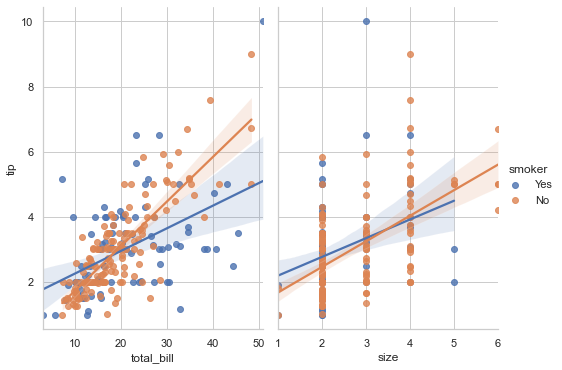

```python
sns.pairplot(tips, x_vars=["total_bill", "size"], y_vars=["tip"],
             hue="smoker", height=5, aspect=.7, kind="reg");
```

# Plotting with categorical data

We can use scatterplots and regression model fits to visualize the relationship between two variables and how it changes across levels of additional categorical variables. However, what if one of the main variables you are interested in is categorical? In this case, the scatterplot and regression model approach won't work. There are several options, however, for visualizing such a relationship.

It's useful to divide seaborn's categorical plots into three groups: those that show each observation at each level of the categorical variable, those that show an abstract representation of each *distribution* of observations, and those that apply a statistical estimation to show a measure of central tendency and confidence interval. The first includes the functions **swarmplot** and **stripplot**, the second includes **boxplot** and **violinplot**, and the third includes **barplot** and **pointplot**. These functions all share a basic API for how they accept data, although each has specific parameters that control the particulars of the visualization that is applied to that data.

Much like the relationship between **regplot** and **lmplot**, in seaborn there are both relatively low-level and relatively high-level approaches for making categorical plots. The functions named above are all low-level in that they plot onto a specific matplotlib axes. There is also the higher-level **factorplot**, which combines these functions with a **FacetGrid** to apply a categorical plot across a grid of figure panels.

```python
%matplotlib inline
```

```python
import numpy as np
import pandas as pd
import matplotlib as mpl
import matplotlib.pyplot as plt
```

```python
import seaborn as sns
sns.set(style="whitegrid", color_codes=True)
```

```python
np.random.seed(sum(map(ord, "categorical")))
```

```python
titanic = sns.load_dataset("titanic")
tips = sns.load_dataset("tips")
iris = sns.load_dataset("iris")
```

## Categorical scatterplots

A simple way to show the the values of some quantitative variable across the levels of a categorical variable uses ***`stripplot`, which generalizes a scatterplot to the case where one of the variables is categorical:

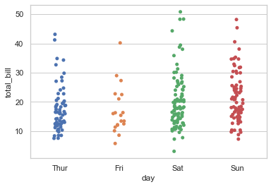

```python
sns.stripplot(x="day", y="total_bill", data=tips);
```

In a strip plot, the scatterplot points will usually overlap. This makes it difficult to see the full distribution of data. One easy solution is to adjust the positions (only along the categorical axis) using some random "jitter":

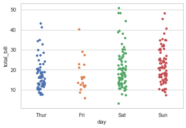

```python
sns.stripplot(x="day", y="total_bill", data=tips, jitter=True);
```

A different approach would be to use the function ***`swarmplot`, which positions each scatterplot point on the categorical axis with an algorithm that avoids overlapping points:

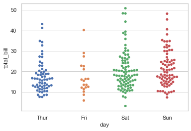

```python
sns.swarmplot(x="day", y="total_bill", data=tips);
```

It's also possible to add a nested categorical variable with the `hue` parameter. Above the color and position on the categorical axis are redundant, but now each provides information about one of the two variables:

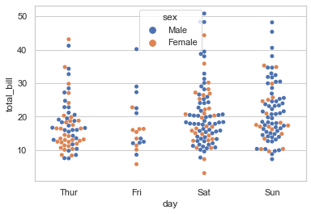

```python
sns.swarmplot(x="day", y="total_bill", hue="sex", data=tips);
```

In general, the seaborn categorical plotting functions try to infer the order of categories from the data. If your data have a pandas `Categorical` datatype, then the default order of the categories can be set there. For other datatypes, string-typed categories will be plotted in the order they appear in the DataFrame, but categories that look numerical will be sorted:

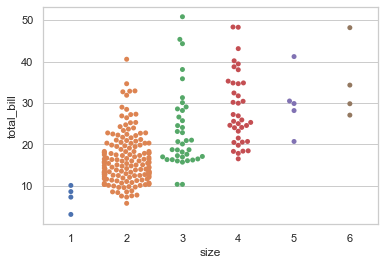

```python
sns.swarmplot(x="size", y="total_bill", data=tips);
```

With these plots, it's often helpful to put the categorical variable on the vertical axis (this is particularly useful when the category names are relatively long or there are many categories). You can force an orientation using the `orient` keyword, but usually plot orientation can be inferred from the datatypes of the variables passed to `x` and/or `y`:

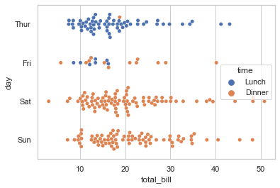

```python
sns.swarmplot(x="total_bill", y="day", hue="time", data=tips);
```

## Distributions of observations within categories

At a certain point, the categorical scatterplot approach becomes limited in the information it can provide about the distribution of values within each category. There are several ways to summarize this information in ways that facilitate easy comparisons across the category levels. These generalize some of the approaches we discussed in the :ref:`chapter <distribution_tutorial>` to the case where we want to quickly compare across several distributions.

The first is the familiar ***`boxplot`. This kind of plot shows the three quartile values of the distribution along with extreme values. The "whiskers" extend to points that lie within 1.5 IQRs of the lower and upper quartile, and then observations that fall outside this range are displayed independently. Importantly, this means that each value in the boxplot corresponds to an actual observation in the data:

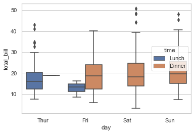

```python
sns.boxplot(x="day", y="total_bill", hue="time", data=tips);
```

For boxplots, the assumption when using a `hue` variable is that it is nested within the `x` or `y` variable. This means that by default, the boxes for different levels of `hue` will be offset, as you can see above. If your `hue` variable is not nested, you can set the `dodge` parameter to disable offsetting:

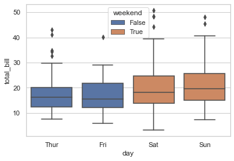

```python
tips["weekend"] = tips["day"].isin(["Sat", "Sun"])
sns.boxplot(x="day", y="total_bill", hue="weekend", data=tips, dodge=False);
```

A different approach is a ***`violinplot`, which combines a boxplot with the kernel density estimation procedure described in the :ref:`distributions <distribution_tutorial>` tutorial:

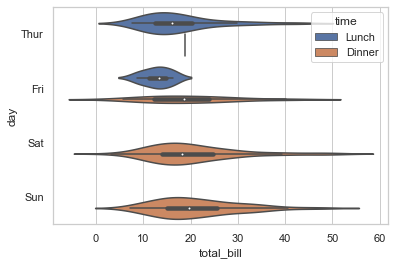

```python
sns.violinplot(x="total_bill", y="day", hue="time", data=tips);
```

This approach uses the kernel density estimate to provide a better description of the distribution of values. Additionally, the quartile and whikser values from the boxplot are shown inside the violin. Because the violinplot uses a KDE, there are some other parameters that may need tweaking, adding some complexity relative to the straightforward boxplot:

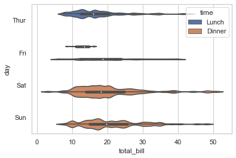

```python
sns.violinplot(x="total_bill", y="day", hue="time", data=tips,
               bw=.1, scale="count", scale_hue=False);
```

It's also possible to "split" the violins when the hue parameter has only two levels, which can allow for a more efficient use of space:

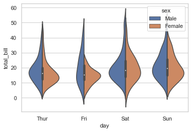

```python
sns.violinplot(x="day", y="total_bill", hue="sex", data=tips, split=True);
```

Finally, there are several options for the plot that is drawn on the interior of the violins, including ways to show each individual observation instead of the summary boxplot values:

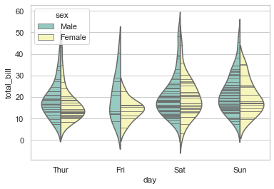

```python
sns.violinplot(x="day", y="total_bill", hue="sex", data=tips,
               split=True, inner="stick", palette="Set3");
```

It can also be useful to combine *`swarmplot` or* `swarmplot` with *`violinplot` or* `boxplot` to show each observation along with a summary of the distribution:

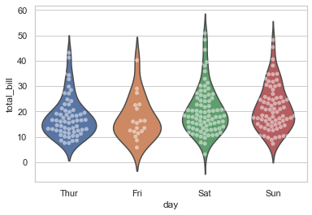

```python
sns.violinplot(x="day", y="total_bill", data=tips, inner=None)
sns.swarmplot(x="day", y="total_bill", data=tips, color="w", alpha=.5);
```

## Statistical estimation within categories

Often, rather than showing the distribution within each category, you might want to show the central tendency of the values. Seaborn has two main ways to show this information, but importantly, the basic API for these functions is identical to that for the ones discussed above.

## Bar plots

A familiar style of plot that accomplishes this goal is a bar plot. In seaborn, the *`barplot`* function operates on a full dataset and shows an arbitrary estimate, using the mean by default. When there are multiple observations in each category, it also uses bootstrapping to compute a confidence interval around the estimate and plots that using error bars:

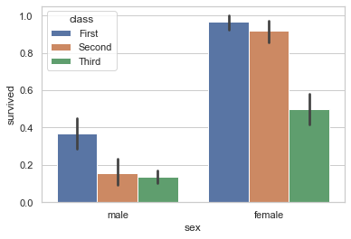

```python
sns.barplot(x="sex", y="survived", hue="class", data=titanic);
```

A special case for the bar plot is when you want to show the number of observations in each category rather than computing a statistic for a second variable. This is similar to a histogram over a categorical, rather than quantitative, variable. In seaborn, it's easy to do so with the ***`countplot` function:

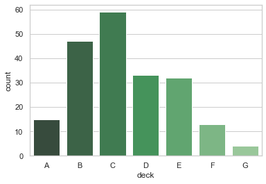

```python
sns.countplot(x="deck", data=titanic, palette="Greens_d");
```

Both *`barplot`* and *`countplot`* can be invoked with all of the options discussed above, along with others that are demonstrated in the detailed documentation for each function:

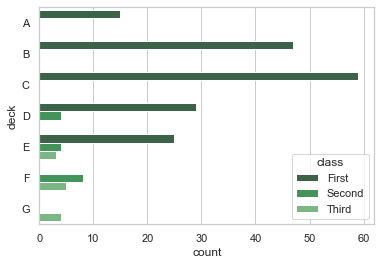

```python
sns.countplot(y="deck", hue="class", data=titanic, palette="Greens_d");
```

## Point plots

An alternative style for visualizing the same information is offered by the *`pointplot`* function. This function also encodes the value of the estimate with height on the other axis, but rather than show a full bar it just plots the point estimate and confidence interval. Additionally, pointplot connects points from the same `hue` category. This makes it easy to see how the main relationship is changing as a function of a second variable, because your eyes are quite good at picking up on differences of slopes:

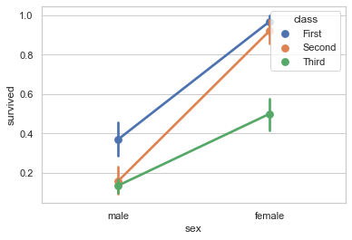

```python
sns.pointplot(x="sex", y="survived", hue="class", data=titanic);
```

To make figures that reproduce well in black and white, it can be good to use different markers and line styles for the levels of the `hue` category:

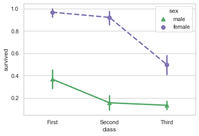

```python
sns.pointplot(x="class", y="survived", hue="sex", data=titanic,
              palette={"male": "g", "female": "m"},
              markers=["^", "o"], linestyles=["-", "--"]);
```

## Plotting "wide-form" data

While using "long-form" or "tidy" data is preferred, these functions can also by applied to "wide-form" data in a variety of formats, including pandas DataFrames or two-dimensional numpy arrays. These objects should be passed directly to the `data` parameter:

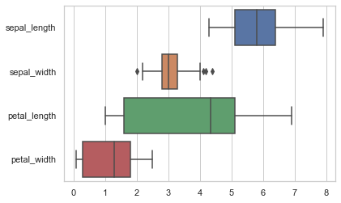

```python
sns.boxplot(data=iris, orient="h");
```

Additionally, these functions accept vectors of Pandas or numpy objects rather than variables in a `DataFrame`:

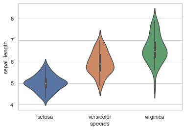

```python
sns.violinplot(x=iris.species, y=iris.sepal_length);
```

To control the size and shape of plots made by the functions discussed above, you must set up the figure yourself using matplotlib commands. Of course, this also means that the plots can happily coexist in a multi-panel figure with other kinds of plots:

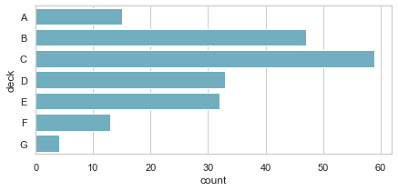

```python
f, ax = plt.subplots(figsize=(7, 3))
sns.countplot(y="deck", data=titanic, color="c");
```

## Drawing multi-panel categorical plots

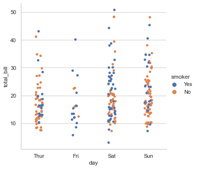

```python
sns.catplot(x="day", y="total_bill", hue="smoker", data=tips);
```

However, the `kind` parameter lets you chose any of the kinds of plots discussed above:

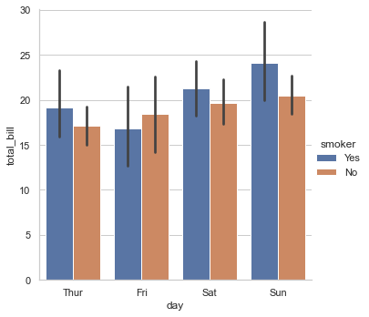

```python
sns.factorplot(x="day", y="total_bill", hue="smoker", data=tips, kind="bar");
```

The main advantage of using a *`factorplot`* is that it is very easy to "facet" the plot and investigate the role of other categorical variables:

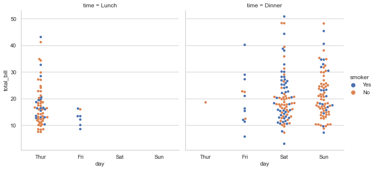

```python
sns.factorplot(x="day", y="total_bill", hue="smoker",
               col="time", data=tips, kind="swarm");
```

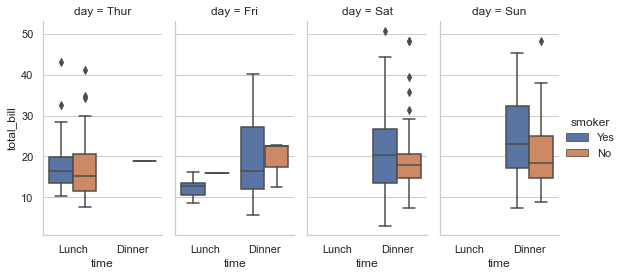

```python
sns.catplot(x="time", y="total_bill", hue="smoker",
               col="day", data=tips, kind="box", height=4, aspect=.5);
```

It is important to note that you could also make this plot by using *`boxplot`* and :class:`FacetGrid` directly. However, special care must be taken to ensure that the order of the categorical variables is enforced in each facet, either by using data with a `Categorical` datatype or by passing `order` and `hue_order`.

Because of the generalized API of the categorical plots, they should be easy to apply to other more complex contexts. For example, they are easily combined with a :class:`PairGrid` to show categorical relationships across several different variables:

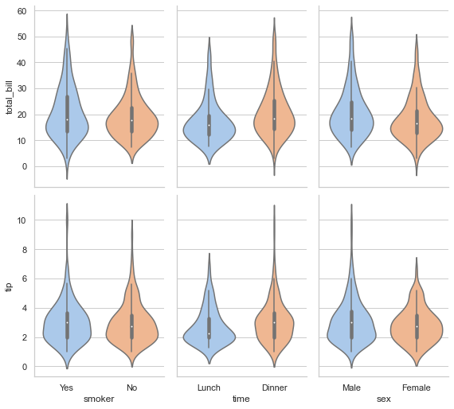

```python
g = sns.PairGrid(tips,
                 x_vars=["smoker", "time", "sex"],
                 y_vars=["total_bill", "tip"],
                 aspect=.75, height=3.5)
g.map(sns.violinplot, palette="pastel");
```